# Chapter 3: Physiology

# Results

#### (A) Coral host and algal endosymbiont physiology by parameter

> Protein content (mg/cm2) measured in coral host tissue at the start of the experiment (T0) was not clearly different than the that in coral hosts maintained in the control treatments (400 uatm at 28C) for the 93 day experiment (T90) in any coral species. Coral host tissue of *P. strigosa* reared at 31C exhibited consistently lower protein content than coral hosts reared at 28C in the same pCO2 treatments, however there was no statistically clear difference between pCO2 treatments at either temperature (**Figure 1A**). Coral host protein content did not clearly differ between treatments in *S. siderea, P.astreoides,* or *U. tenuifolia*. Lipid content (mg/cm2) measured in *S. siderea* coral host tissue taken at T0 was lower than in coral hosts reared in the control treatment at T90 (**Figure 1B**). There was no clear difference in coral host lipid content from T0 to T90 in the control treatments for *P. strigosa, P. astreoides,* and *U. tenuifolia*. No statistically clear temperature or pCO2 effect on coral host lipid content was observed at T90 in the four coral species (**Figure 1B**). Coral host carbohydrate content (mg/cm2) of *P. astreoides* and *U. tenuifolia* at T0 was higher than in coral hosts reared under the control treatment at T90 (**Figure 1C**), however, there was no difference between T0 and T90 control coral hosts in *S. siderea* or *P. strigosa*. There was no overall effect of pCO2 or temperature on coral host carbohydrate content in any of the four species examined (**Figure 1C**).

#### (B) Total coral host energy reserves

> Coral host total tissue energy reserves (mg/cm2) was calculated as the sum of each protein, lipid, and carbohydrate value per coral host. Total host energy reserves of *P. astreoides* and *U. tenuifolia* at T0 were clearly greater than the total energy reserves quantified in coral hosts maintained under at control treatment at T90 (**Figure 2A**). There was not statistically clear difference in total energy reserves between T0 and T90 control coral hosts in both *S. siderea* and *P. strigosa*. Elevated temperature (31C) resulted in a statistically clear reduction in total coral host energy reserves in only *P. strigosa* across all pCO2 treatments (**Figure 2A**). No overall effect of pCO2 was quantified in any of the four species examined.

#### (C) Total algal endosymbiont physiology

> Calculated chlorophyll a content per algal endosymbiont cell (ug/10^6 cells) represents total algal endosymbiont physiology and is a measure of the efficiency of the endosymbionts associated with each coral fragment. Total algal endosymbiont physiology of *P. strigosa* was lower at T0 than in the control treatment fragments at T90 (**Figure 2B**). Conversely, *S. siderea, P.astreoides,* and *U. tenuifolia* total algal endosymbiont physiology did not exhibit a statistically clear difference between T0 and fragments maintained under the control teratment at T90. Algal endosymbionts associated with *P. strigosa* fragments maintained at 31C exhibited greater total endosymbiont physiology than those reared at 28C across all pCO2 treatment (**Figure 2B**), while temerature did not alter the total endosymbiont physiology associated with the other species examined. No statstically clear effect of pCO2 on the total algal endosymbiont was observed on any of the four species.

# Figures:

### Figure 1

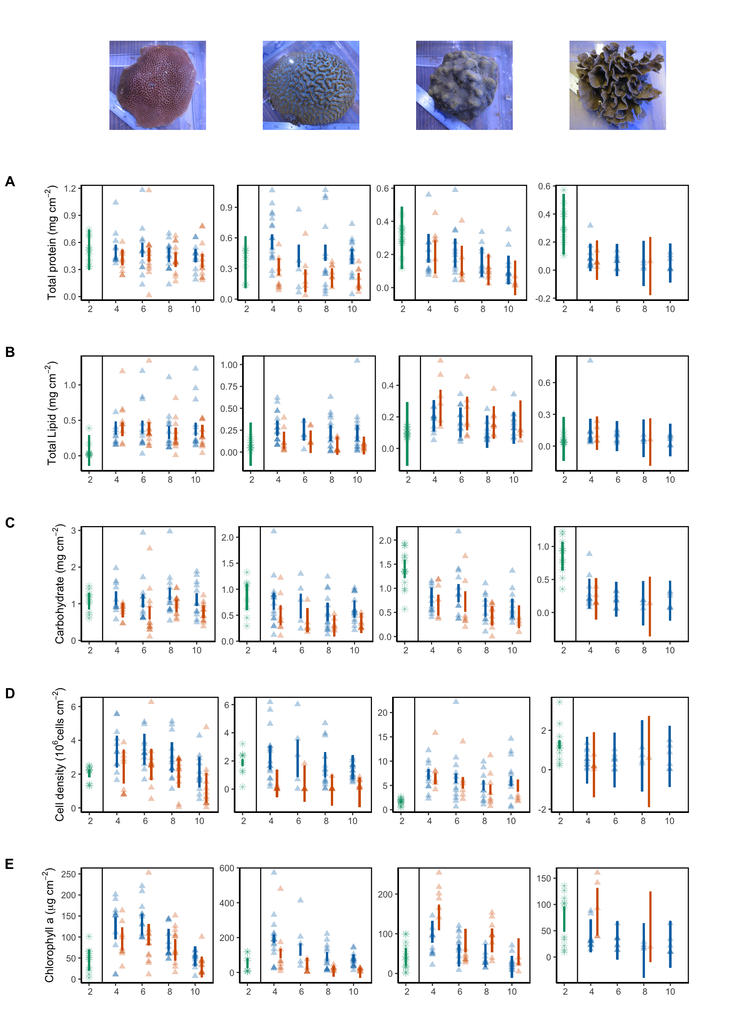

Modeled 95% confidence interval of (A) total protein (mg/cm2), (B) total lipid (mg/cm2), (C) total carbohydrate (mg/cm2), (D) cell density (10^6 cells/cm2), and (E) Chlorophyll a (ug/cm2) for each coral species, with individual coral fragment physiology denoted by points. Blue denotes 28C and red denotes 31C, with *p*CO2 treatment along the x axis.

### Figure 2

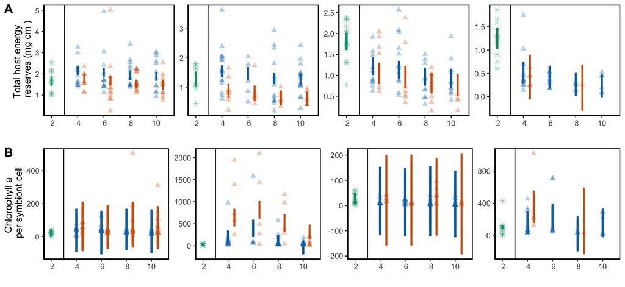

Modeled 95% confidence interval of (A) total host energy reserves (mg/cm2) and (B) chlorophyll a per symbiont cell (ug/10^6 cells) for *S. siderea*, *P. strigosa*, *P. astreoides*, and *U. tenuifolia* for each coral species, with individual coral fragment physiology denoted by points. Blue denotes 28C and red denotes 31C, with *p*CO2 treatment along the x axis.

# Tables:

Table 1. T0 modelled mean and 95% confidence intervals for each physiological parameter per species

| parameter | N | mean | lower 95% | upper 95% |
| --- | --- | --- | --- | --- |
| **(a) SSID** |  |  |  |  |
| carb | 10 | 1.07 | 0.85 | 1.29 |
| lipid | 10 | 0.07 | -0.14 | 0.29 |
| pro | 10 | 0.52 | 0.30 | 0.74 |
| chla | 10 | 44.85 | 20.14 | 70.66 |
| den | 10 | 2.04 | 1.82 | 2.26 |
| host | 10 | 1.67 | 1.45 | 1.88 |
| symb | 10 | 22.27 | -1.92 | 46.63 |
| **(b) PSTR** |  |  |  |  |
| carb | 8 | 0.85 | 0.60 | 1.10 |
| lipid | 8 | 0.08 | -0.16 | 0.34 |
| pro | 8 | 0.35 | 0.11 | 0.62 |
| chla | 8 | 51.72 | 23.62 | 80.45 |
| den | 8 | 1.87 | 1.63 | 2.13 |
| host | 8 | 1.28 | 1.04 | 1.53 |
| symb | 8 | 33.13 | 5.82 | 62.74 |
| **(c) PAST** |  |  |  |  |
| carb | 14 | 1.40 | 1.21 | 1.59 |
| lipid | 13 | 0.10 | -0.11 | 0.29 |
| pro | 14 | 0.30 | 0.11 | 0.49 |
| chla | 14 | 42.28 | 21.01 | 63.80 |
| den | 14 | 1.63 | 1.45 | 1.82 |
| host | 13 | 1.82 | 1.61 | 2.02 |
| symb | 14 | 28.27 | 7.08 | 49.22 |
| **(d) UTEN** |  |  |  |  |
| carb | 11 | 0.85 | 0.64 | 1.07 |
| lipid | 11 | 0.06 | -0.14 | 0.27 |
| pro | 11 | 0.33 | 0.11 | 0.54 |
| chla | 11 | 72.08 | 48.05 | 95.90 |
| den | 11 | 1.29 | 1.08 | 1.50 |
| host | 11 | 1.25 | 1.03 | 1.47 |
| symb | 11 | 100.33 | 77.13 | 124.94 |

Table 2. T90 modelled mean coral host protein content and 95% confidence intervals for each species

| treatment | N | mean | lower 95% | upper 95% |
| --- | --- | --- | --- | --- |
| **(a) SSID** |  |  |  |  |
| 288_28 | 11 | 0.49 | 0.41 | 0.57 |
| 311_31 | 9 | 0.44 | 0.35 | 0.52 |
| 3285_28 | 12 | 0.45 | 0.38 | 0.53 |
| 3309_31 | 12 | 0.40 | 0.32 | 0.47 |
| 405_31 | 12 | 0.46 | 0.39 | 0.54 |
| 447_28 | 12 | 0.52 | 0.44 | 0.60 |
| 673_28 | 13 | 0.47 | 0.39 | 0.54 |
| 701_31 | 12 | 0.41 | 0.33 | 0.49 |
| **(b) PSTR** |  |  |  |  |
| 288_28 | 16 | 0.56 | 0.49 | 0.63 |
| 311_31 | 9 | 0.32 | 0.23 | 0.40 |
| 3285_28 | 16 | 0.42 | 0.34 | 0.49 |
| 3309_31 | 8 | 0.17 | 0.08 | 0.26 |
| 405_31 | 6 | 0.18 | 0.07 | 0.29 |
| 447_28 | 5 | 0.42 | 0.31 | 0.53 |
| 673_28 | 14 | 0.45 | 0.38 | 0.53 |
| 701_31 | 7 | 0.21 | 0.11 | 0.30 |
| **(c) PAST** |  |  |  |  |
| 288_28 | 11 | 0.24 | 0.15 | 0.32 |
| 311_31 | 6 | 0.19 | 0.08 | 0.28 |
| 3285_28 | 12 | 0.11 | 0.02 | 0.19 |
| 3309_31 | 4 | 0.06 | -0.05 | 0.16 |
| 405_31 | 7 | 0.16 | 0.07 | 0.25 |
| 447_28 | 12 | 0.21 | 0.12 | 0.30 |
| 673_28 | 10 | 0.16 | 0.06 | 0.24 |
| 701_31 | 9 | 0.11 | 0.01 | 0.20 |
| **(d) UTEN** |  |  |  |  |
| 288_28 | 11 | 0.09 | -0.01 | 0.19 |
| 311_31 | 5 | 0.07 | -0.07 | 0.21 |
| 3285_28 | 6 | 0.05 | -0.09 | 0.19 |
| 447_28 | 8 | 0.07 | -0.04 | 0.19 |
| 673_28 | 4 | 0.05 | -0.11 | 0.21 |
| 701_31 | 1 | 0.03 | -0.18 | 0.24 |

Table 3. T90 modelled mean coral host lipid content and 95% confidence intervals for each species

| treatment | N | mean | lower 95% | upper 95% |
| --- | --- | --- | --- | --- |
| **(a) SSID** |  |  |  |  |
| 288_28 | 11 | 0.39 | 0.30 | 0.49 |
| 311_31 | 9 | 0.37 | 0.28 | 0.47 |
| 3285_28 | 12 | 0.37 | 0.28 | 0.46 |
| 3309_31 | 12 | 0.35 | 0.26 | 0.44 |
| 405_31 | 12 | 0.39 | 0.30 | 0.47 |
| 447_28 | 12 | 0.41 | 0.32 | 0.50 |
| 673_28 | 13 | 0.33 | 0.24 | 0.42 |
| 701_31 | 12 | 0.31 | 0.22 | 0.40 |
| **(b) PSTR** |  |  |  |  |
| 288_28 | 16 | 0.28 | 0.19 | 0.36 |
| 311_31 | 9 | 0.13 | 0.04 | 0.23 |
| 3285_28 | 15 | 0.22 | 0.13 | 0.31 |
| 3309_31 | 8 | 0.08 | -0.03 | 0.17 |
| 405_31 | 5 | 0.12 | -0.01 | 0.24 |
| 447_28 | 5 | 0.26 | 0.13 | 0.39 |
| 673_28 | 14 | 0.22 | 0.13 | 0.30 |
| 701_31 | 7 | 0.07 | -0.03 | 0.18 |
| **(c) PAST** |  |  |  |  |
| 288_28 | 11 | 0.21 | 0.11 | 0.31 |
| 311_31 | 6 | 0.26 | 0.14 | 0.37 |
| 3285_28 | 12 | 0.13 | 0.03 | 0.23 |
| 3309_31 | 4 | 0.18 | 0.07 | 0.30 |
| 405_31 | 7 | 0.22 | 0.12 | 0.33 |
| 447_28 | 12 | 0.17 | 0.07 | 0.26 |
| 673_28 | 10 | 0.11 | 0.00 | 0.21 |
| 701_31 | 9 | 0.16 | 0.06 | 0.27 |
| **(d) UTEN** |  |  |  |  |
| 288_28 | 11 | 0.15 | 0.03 | 0.26 |
| 311_31 | 5 | 0.12 | -0.04 | 0.28 |
| 3285_28 | 6 | 0.06 | -0.10 | 0.21 |
| 447_28 | 8 | 0.09 | -0.05 | 0.23 |
| 673_28 | 4 | 0.07 | -0.10 | 0.25 |
| 701_31 | 1 | 0.05 | -0.19 | 0.26 |

Table 4. T90 modelled mean coral host carbohydrate content and 95% confidence intervals for each species

| treatment | N | mean | lower 95% | upper 95% |
| --- | --- | --- | --- | --- |
| **(a) SSID** |  |  |  |  |
| 288_28 | 11 | 1.15 | 0.97 | 1.33 |
| 311_31 | 8 | 0.82 | 0.63 | 1.02 |
| 3285_28 | 12 | 1.11 | 0.94 | 1.28 |
| 3309_31 | 12 | 0.78 | 0.61 | 0.95 |
| 405_31 | 12 | 0.75 | 0.58 | 0.93 |
| 447_28 | 12 | 1.08 | 0.90 | 1.25 |
| 673_28 | 13 | 1.27 | 1.11 | 1.43 |
| 701_31 | 12 | 0.94 | 0.78 | 1.11 |
| **(b) PSTR** |  |  |  |  |
| 288_28 | 16 | 0.77 | 0.60 | 0.92 |
| 311_31 | 9 | 0.49 | 0.31 | 0.68 |
| 3285_28 | 16 | 0.62 | 0.46 | 0.78 |
| 3309_31 | 8 | 0.35 | 0.16 | 0.54 |
| 405_31 | 6 | 0.40 | 0.17 | 0.64 |
| 447_28 | 5 | 0.67 | 0.44 | 0.91 |
| 673_28 | 14 | 0.56 | 0.39 | 0.74 |
| 701_31 | 7 | 0.29 | 0.09 | 0.49 |
| **(c) PAST** |  |  |  |  |
| 288_28 | 11 | 0.82 | 0.63 | 1.01 |
| 311_31 | 6 | 0.65 | 0.44 | 0.87 |
| 3285_28 | 12 | 0.58 | 0.39 | 0.78 |
| 3309_31 | 4 | 0.41 | 0.17 | 0.64 |
| 405_31 | 7 | 0.72 | 0.52 | 0.94 |
| 447_28 | 12 | 0.89 | 0.71 | 1.08 |
| 673_28 | 10 | 0.60 | 0.41 | 0.80 |
| 701_31 | 9 | 0.43 | 0.23 | 0.63 |
| **(d) UTEN** |  |  |  |  |
| 288_28 | 11 | 0.29 | 0.06 | 0.51 |
| 311_31 | 5 | 0.22 | -0.11 | 0.52 |
| 3285_28 | 6 | 0.18 | -0.12 | 0.48 |
| 447_28 | 8 | 0.20 | -0.06 | 0.46 |
| 673_28 | 4 | 0.15 | -0.19 | 0.48 |
| 701_31 | 1 | 0.08 | -0.36 | 0.54 |

Table 5. T90 modelled mean algal endosymbiont cell density and 95% confidence intervals for each species

| treatment | N | mean | lower 95% | upper 95% |
| --- | --- | --- | --- | --- |
| **(a) SSID** |  |  |  |  |
| 288_28 | 11 | 3.33 | 2.39 | 4.27 |
| 311_31 | 9 | 2.44 | 1.45 | 3.43 |
| 3285_28 | 12 | 2.08 | 1.21 | 3.00 |
| 3309_31 | 12 | 1.20 | 0.32 | 2.06 |
| 405_31 | 12 | 2.59 | 1.64 | 3.49 |
| 447_28 | 12 | 3.48 | 2.54 | 4.39 |
| 673_28 | 13 | 2.96 | 2.10 | 3.88 |
| 701_31 | 12 | 2.08 | 1.21 | 2.97 |
| **(b) PSTR** |  |  |  |  |
| 288_28 | 16 | 2.23 | 1.40 | 3.08 |
| 311_31 | 9 | 0.43 | -0.58 | 1.39 |
| 3285_28 | 16 | 1.57 | 0.72 | 2.40 |
| 3309_31 | 8 | -0.23 | -1.28 | 0.82 |
| 405_31 | 6 | 0.42 | -0.90 | 1.68 |
| 447_28 | 5 | 2.22 | 0.87 | 3.51 |
| 673_28 | 14 | 1.72 | 0.83 | 2.63 |
| 701_31 | 7 | -0.08 | -1.17 | 1.02 |
| **(c) PAST** |  |  |  |  |
| 288_28 | 11 | 7.30 | 6.27 | 8.35 |
| 311_31 | 6 | 6.39 | 5.26 | 7.56 |
| 3285_28 | 12 | 5.88 | 4.84 | 6.87 |
| 3309_31 | 4 | 4.97 | 3.71 | 6.21 |
| 405_31 | 6 | 5.56 | 4.38 | 6.71 |
| 447_28 | 12 | 6.46 | 5.46 | 7.45 |
| 673_28 | 10 | 5.06 | 4.02 | 6.05 |
| 701_31 | 8 | 4.15 | 3.11 | 5.19 |
| **(d) UTEN** |  |  |  |  |
| 288_28 | 11 | 0.55 | -0.69 | 1.66 |
| 311_31 | 5 | 0.27 | -1.39 | 1.90 |
| 3285_28 | 6 | 0.66 | -0.87 | 2.23 |
| 447_28 | 8 | 0.47 | -0.89 | 1.88 |
| 673_28 | 4 | 0.69 | -1.10 | 2.51 |
| 701_31 | 1 | 0.41 | -1.90 | 2.73 |

Table 6. T90 modelled mean algal endosymbiont chlorophyll a content and 95% confichlace intervals for each species

| treatment | N | mean | lower 95% | upper 95% |
| --- | --- | --- | --- | --- |
| **(a) SSID** |  |  |  |  |
| 288_28 | 11 | 120.80 | 94.79 | 146.99 |
| 311_31 | 9 | 95.85 | 68.17 | 122.69 |
| 3285_28 | 12 | 53.87 | 30.70 | 77.82 |
| 3309_31 | 12 | 28.92 | 4.20 | 53.30 |
| 405_31 | 12 | 105.06 | 80.32 | 130.61 |
| 447_28 | 12 | 130.01 | 104.87 | 155.20 |
| 673_28 | 13 | 94.55 | 68.73 | 118.90 |
| 701_31 | 12 | 69.60 | 44.16 | 95.17 |
| **(b) PSTR** |  |  |  |  |
| 288_28 | 16 | 193.51 | 169.96 | 217.27 |
| 311_31 | 9 | 109.96 | 83.65 | 136.74 |
| 3285_28 | 16 | 81.01 | 57.01 | 104.12 |
| 3309_31 | 8 | -2.54 | -30.87 | 23.97 |
| 405_31 | 6 | 47.86 | 13.46 | 84.20 |
| 447_28 | 5 | 131.42 | 95.82 | 166.70 |
| 673_28 | 14 | 90.14 | 65.22 | 115.42 |
| 701_31 | 7 | 6.59 | -24.04 | 35.78 |
| **(c) PAST** |  |  |  |  |
| 288_28 | 11 | 104.48 | 77.16 | 132.06 |
| 311_31 | 6 | 142.68 | 108.91 | 173.14 |
| 3285_28 | 12 | 17.34 | -10.99 | 44.15 |
| 3309_31 | 4 | 55.54 | 20.78 | 88.39 |
| 405_31 | 7 | 84.00 | 53.75 | 112.29 |
| 447_28 | 12 | 45.80 | 17.86 | 73.38 |
| 673_28 | 10 | 45.27 | 15.84 | 73.53 |
| 701_31 | 9 | 83.47 | 53.13 | 112.94 |
| **(d) UTEN** |  |  |  |  |
| 288_28 | 11 | 40.19 | 9.14 | 71.78 |
| 311_31 | 5 | 85.87 | 41.22 | 131.39 |
| 3285_28 | 6 | 24.62 | -20.33 | 68.34 |
| 447_28 | 8 | 30.00 | -5.02 | 68.09 |
| 673_28 | 4 | 11.82 | -39.63 | 64.36 |
| 701_31 | 1 | 57.50 | -9.86 | 124.90 |

Table 7. Total coral host physiology at T90 modelled mean and 95% confidence intervals for each physiological parameter per species

| treatment | N | mean | lower 95% | upper 95% |
| --- | --- | --- | --- | --- |
| **(a) SSID** |  |  |  |  |
| 288_28 | 11 | 2.17 | 1.96 | 2.37 |
| 311_31 | 8 | 1.76 | 1.54 | 1.98 |
| 3285_28 | 12 | 1.88 | 1.68 | 2.09 |
| 3309_31 | 12 | 1.47 | 1.27 | 1.69 |
| 405_31 | 12 | 1.67 | 1.46 | 1.89 |
| 447_28 | 12 | 2.08 | 1.87 | 2.28 |
| 673_28 | 13 | 1.93 | 1.72 | 2.13 |
| 701_31 | 12 | 1.52 | 1.30 | 1.73 |
| **(b) PSTR** |  |  |  |  |
| 288_28 | 16 | 1.55 | 1.35 | 1.74 |
| 311_31 | 9 | 0.88 | 0.64 | 1.11 |
| 3285_28 | 15 | 1.26 | 1.06 | 1.46 |
| 3309_31 | 8 | 0.59 | 0.36 | 0.84 |
| 405_31 | 5 | 0.79 | 0.53 | 1.05 |
| 447_28 | 5 | 1.46 | 1.23 | 1.69 |
| 673_28 | 14 | 1.30 | 1.11 | 1.49 |
| 701_31 | 7 | 0.64 | 0.38 | 0.88 |
| **(c) PAST** |  |  |  |  |
| 288_28 | 11 | 1.22 | 1.01 | 1.43 |
| 311_31 | 6 | 1.05 | 0.79 | 1.30 |
| 3285_28 | 12 | 0.93 | 0.71 | 1.15 |
| 3309_31 | 4 | 0.76 | 0.50 | 1.03 |
| 405_31 | 7 | 0.96 | 0.71 | 1.22 |
| 447_28 | 12 | 1.13 | 0.91 | 1.34 |
| 673_28 | 10 | 0.97 | 0.75 | 1.18 |
| 701_31 | 9 | 0.80 | 0.56 | 1.05 |
| **(d) UTEN** |  |  |  |  |
| 288_28 | 11 | 0.51 | 0.28 | 0.74 |
| 311_31 | 5 | 0.42 | -0.05 | 0.90 |
| 3285_28 | 6 | 0.23 | -0.02 | 0.47 |
| 447_28 | 8 | 0.42 | 0.17 | 0.66 |
| 673_28 | 4 | 0.27 | 0.01 | 0.52 |
| 701_31 | 1 | 0.18 | -0.30 | 0.68 |

Table 8. Total algal endosymbiont physiology at T90 modelled mean and 95% confidence intervals for each physiological parameter per species

| treatment | N | mean | lower 95% | upper 95% |
| --- | --- | --- | --- | --- |
| **(a) SSID** |  |  |  |  |
| 288_28 | 11 | 32.71 | -81.50 | 154.85 |
| 311_31 | 9 | 57.10 | -78.11 | 194.36 |
| 3285_28 | 12 | 30.02 | -91.49 | 152.34 |
| 3309_31 | 12 | 56.83 | -62.38 | 174.35 |
| 405_31 | 12 | 50.95 | -65.98 | 173.77 |
| 447_28 | 12 | 25.00 | -94.96 | 144.36 |
| 673_28 | 13 | 46.97 | -64.96 | 158.55 |
| 701_31 | 12 | 74.21 | -51.05 | 196.08 |
| **(b) PSTR** |  |  |  |  |
| 288_28 | 16 | 233.33 | 127.23 | 338.29 |
| 311_31 | 5 | 644.27 | 457.45 | 826.87 |
| 3285_28 | 16 | -67.59 | -174.19 | 37.94 |
| 3309_31 | 8 | 327.08 | 175.72 | 474.00 |
| 405_31 | 5 | 816.89 | 627.86 | 999.49 |
| 447_28 | 5 | 401.62 | 211.35 | 580.29 |
| 673_28 | 14 | 123.16 | 14.68 | 234.60 |
| 701_31 | 5 | 508.91 | 332.06 | 698.54 |
| **(c) PAST** |  |  |  |  |
| 288_28 | 11 | 18.41 | -102.40 | 140.40 |
| 311_31 | 6 | 25.66 | -143.65 | 187.00 |
| 3285_28 | 12 | 5.03 | -113.00 | 123.06 |
| 3309_31 | 4 | 12.04 | -193.35 | 207.36 |
| 405_31 | 6 | 18.43 | -147.96 | 184.78 |
| 447_28 | 12 | 11.39 | -108.39 | 132.95 |
| 673_28 | 10 | 19.14 | -109.88 | 145.69 |
| 701_31 | 8 | 28.90 | -110.53 | 171.90 |
| **(d) UTEN** |  |  |  |  |
| 288_28 | 11 | 153.51 | 28.88 | 276.30 |
| 311_31 | 4 | 355.56 | 152.58 | 557.56 |
| 3285_28 | 6 | 143.54 | -19.46 | 306.57 |
| 447_28 | 8 | 221.76 | 68.20 | 370.92 |
| 673_28 | 4 | 8.19 | -194.43 | 208.97 |
| 701_31 | 1 | 175.45 | -238.16 | 595.18 |